# D2SC ICMAs

Rebecca Blum

## ICMA September 3 2026

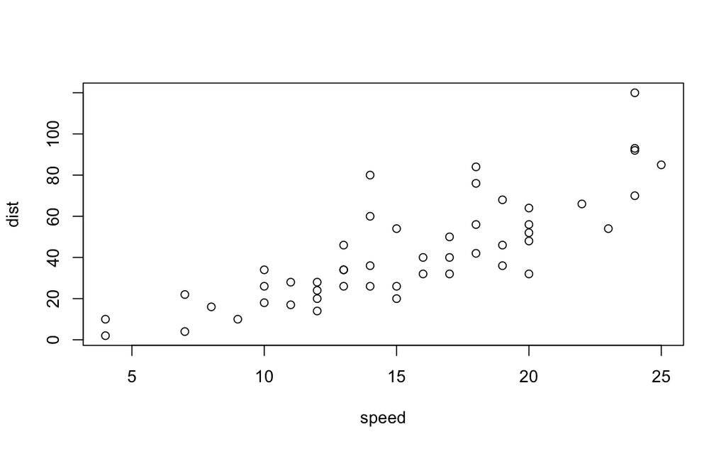

```r
# here I'm plotting data from cars
plot(cars)
```

# I see that in the plot as speed goes up so does distance

## ICMA 9-10-26

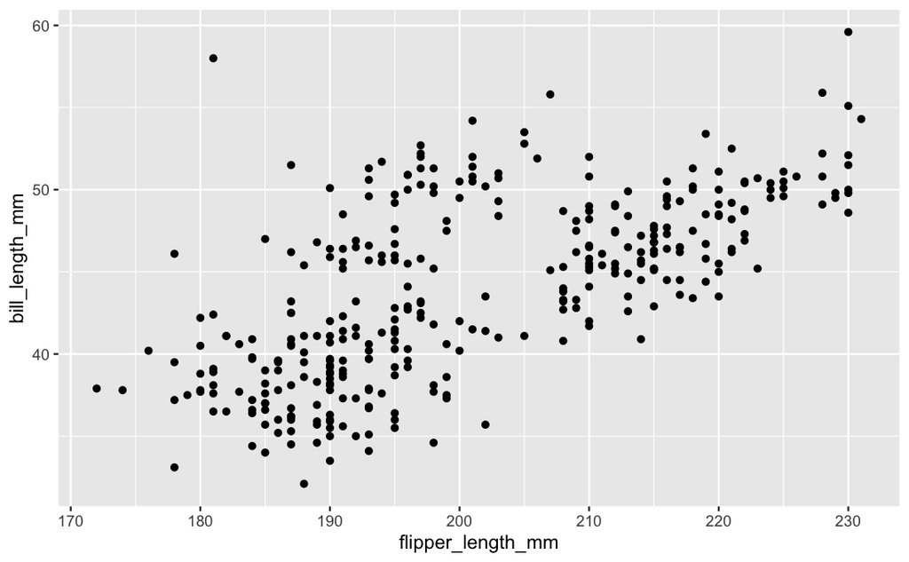

```r
 ggplot(data=penguins, mapping = aes(x= flipper_length_mm,
                                    y= bill_length_mm))+ geom_point()
```

```r
PlantGrowth
```

| weight | group |
| --- | --- |
| 4.17 | ctrl |
| 5.58 | ctrl |
| 5.18 | ctrl |
| 6.11 | ctrl |
| 4.50 | ctrl |
| 4.61 | ctrl |
| 5.17 | ctrl |
| 4.53 | ctrl |
| 5.33 | ctrl |
| 5.14 | ctrl |

[output cut: 20 more lines]

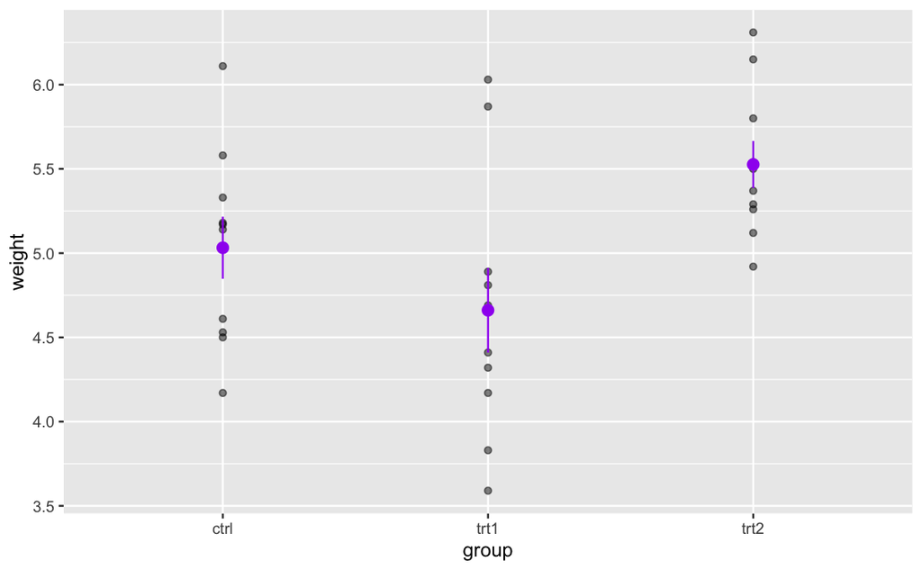

```r
ggplot(data=PlantGrowth, mapping=aes(y=weight, x=group)) + geom_point(alpha=0.5) + stat_summary(geom = "pointrange", fun.data = "mean_se",color="purple")
```

This is tidy data!

## ICMA 9-15-2026

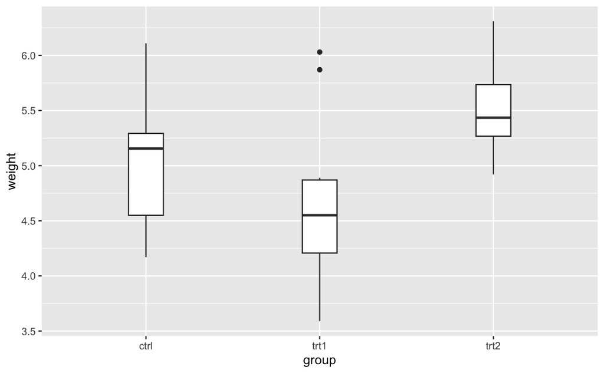

```r
  PlantGrowth |>
  ggplot(aes(y=weight, x = group)) +
  geom_boxplot(width = 0.2)
```

```r
glimpse(flights)
```

```
Rows: 336,776
Columns: 19
$ year           <int> 2013, 2013, 2013, 2013, 2013, 2013, 2013, 2013, 2013, 2013, 2013, 2013, 2013, 201…
$ month          <int> 1, 1, 1, 1, 1, 1, 1, 1, 1, 1, 1, 1, 1, 1, 1, 1, 1, 1, 1, 1, 1, 1, 1, 1, 1, 1, 1, …
$ day            <int> 1, 1, 1, 1, 1, 1, 1, 1, 1, 1, 1, 1, 1, 1, 1, 1, 1, 1, 1, 1, 1, 1, 1, 1, 1, 1, 1, …
$ dep_time       <int> 517, 533, 542, 544, 554, 554, 555, 557, 557, 558, 558, 558, 558, 558, 559, 559, 5…
$ sched_dep_time <int> 515, 529, 540, 545, 600, 558, 600, 600, 600, 600, 600, 600, 600, 600, 600, 559, 6…
$ dep_delay      <dbl> 2, 4, 2, -1, -6, -4, -5, -3, -3, -2, -2, -2, -2, -2, -1, 0, -1, 0, 0, 1, -8, -3, …
$ arr_time       <int> 830, 850, 923, 1004, 812, 740, 913, 709, 838, 753, 849, 853, 924, 923, 941, 702, …
$ sched_arr_time <int> 819, 830, 850, 1022, 837, 728, 854, 723, 846, 745, 851, 856, 917, 937, 910, 706, …
$ arr_delay      <dbl> 11, 20, 33, -18, -25, 12, 19, -14, -8, 8, -2, -3, 7, -14, 31, -4, -8, -7, 12, -6,…
$ carrier        <chr> "UA", "UA", "AA", "B6", "DL", "UA", "B6", "EV", "B6", "AA", "B6", "B6", "UA", "UA…
$ flight         <int> 1545, 1714, 1141, 725, 461, 1696, 507, 5708, 79, 301, 49, 71, 194, 1124, 707, 180…
$ tailnum        <chr> "N14228", "N24211", "N619AA", "N804JB", "N668DN", "N39463", "N516JB", "N829AS", "…
$ origin         <chr> "EWR", "LGA", "JFK", "JFK", "LGA", "EWR", "EWR", "LGA", "JFK", "LGA", "JFK", "JFK…
$ dest           <chr> "IAH", "IAH", "MIA", "BQN", "ATL", "ORD", "FLL", "IAD", "MCO", "ORD", "PBI", "TPA…
$ air_time       <dbl> 227, 227, 160, 183, 116, 150, 158, 53, 140, 138, 149, 158, 345, 361, 257, 44, 337…
$ distance       <dbl> 1400, 1416, 1089, 1576, 762, 719, 1065, 229, 944, 733, 1028, 1005, 2475, 2565, 13…
$ hour           <dbl> 5, 5, 5, 5, 6, 5, 6, 6, 6, 6, 6, 6, 6, 6, 6, 5, 6, 6, 6, 6, 6, 6, 6, 6, 6, 6, 6, …
$ minute         <dbl> 15, 29, 40, 45, 0, 58, 0, 0, 0, 0, 0, 0, 0, 0, 0, 59, 0, 0, 0, 0, 10, 5, 10, 10, …
$ time_hour      <dttm> 2013-01-01 05:00:00, 2013-01-01 05:00:00, 2013-01-01 05:00:00, 2013-01-01 05:00:…
```

```r
flights |>
  filter(month == 1 & day == 1)
```

| year | month | day | dep_time | sched_dep_time | dep_delay | arr_time | sched_arr_time | arr_delay | carrier | flight | tailnum | origin | dest | air_time | distance | hour | minute | time_hour |
| --- | --- | --- | --- | --- | --- | --- | --- | --- | --- | --- | --- | --- | --- | --- | --- | --- | --- | --- |
| 2013 | 1 | 1 | 517 | 515 | 2 | 830 | 819 | 11 | UA | 1545 | N14228 | EWR | IAH | 227 | 1400 | 5 | 15 | 2013-01-01 05:00:00 |
| 2013 | 1 | 1 | 533 | 529 | 4 | 850 | 830 | 20 | UA | 1714 | N24211 | LGA | IAH | 227 | 1416 | 5 | 29 | 2013-01-01 05:00:00 |
| 2013 | 1 | 1 | 542 | 540 | 2 | 923 | 850 | 33 | AA | 1141 | N619AA | JFK | MIA | 160 | 1089 | 5 | 40 | 2013-01-01 05:00:00 |
| 2013 | 1 | 1 | 544 | 545 | -1 | 1004 | 1022 | -18 | B6 | 725 | N804JB | JFK | BQN | 183 | 1576 | 5 | 45 | 2013-01-01 05:00:00 |
| 2013 | 1 | 1 | 554 | 600 | -6 | 812 | 837 | -25 | DL | 461 | N668DN | LGA | ATL | 116 | 762 | 6 | 0 | 2013-01-01 06:00:00 |
| 2013 | 1 | 1 | 554 | 558 | -4 | 740 | 728 | 12 | UA | 1696 | N39463 | EWR | ORD | 150 | 719 | 5 | 58 | 2013-01-01 05:00:00 |
| 2013 | 1 | 1 | 555 | 600 | -5 | 913 | 854 | 19 | B6 | 507 | N516JB | EWR | FLL | 158 | 1065 | 6 | 0 | 2013-01-01 06:00:00 |
| 2013 | 1 | 1 | 557 | 600 | -3 | 709 | 723 | -14 | EV | 5708 | N829AS | LGA | IAD | 53 | 229 | 6 | 0 | 2013-01-01 06:00:00 |
| 2013 | 1 | 1 | 557 | 600 | -3 | 838 | 846 | -8 | B6 | 79 | N593JB | JFK | MCO | 140 | 944 | 6 | 0 | 2013-01-01 06:00:00 |
| 2013 | 1 | 1 | 558 | 600 | -2 | 753 | 745 | 8 | AA | 301 | N3ALAA | LGA | ORD | 138 | 733 | 6 | 0 | 2013-01-01 06:00:00 |

[output cut: 832 more lines]

```r
  flights |>
    arrange(desc(month))
```

| year | month | day | dep_time | sched_dep_time | dep_delay | arr_time | sched_arr_time | arr_delay | carrier | flight | tailnum | origin | dest | air_time | distance | hour | minute | time_hour |
| --- | --- | --- | --- | --- | --- | --- | --- | --- | --- | --- | --- | --- | --- | --- | --- | --- | --- | --- |
| 2013 | 12 | 1 | 13 | 2359 | 14 | 446 | 445 | 1 | B6 | 745 | N715JB | JFK | PSE | 195 | 1617 | 23 | 59 | 2013-12-01 23:00:00 |
| 2013 | 12 | 1 | 17 | 2359 | 18 | 443 | 437 | 6 | B6 | 839 | N593JB | JFK | BQN | 186 | 1576 | 23 | 59 | 2013-12-01 23:00:00 |
| 2013 | 12 | 1 | 453 | 500 | -7 | 636 | 651 | -15 | US | 1895 | N197UW | EWR | CLT | 86 | 529 | 5 | 0 | 2013-12-01 05:00:00 |
| 2013 | 12 | 1 | 520 | 515 | 5 | 749 | 808 | -19 | UA | 1487 | N69804 | EWR | IAH | 193 | 1400 | 5 | 15 | 2013-12-01 05:00:00 |
| 2013 | 12 | 1 | 536 | 540 | -4 | 845 | 850 | -5 | AA | 2243 | N634AA | JFK | MIA | 144 | 1089 | 5 | 40 | 2013-12-01 05:00:00 |
| 2013 | 12 | 1 | 540 | 550 | -10 | 1005 | 1027 | -22 | B6 | 939 | N821JB | JFK | BQN | 189 | 1576 | 5 | 50 | 2013-12-01 05:00:00 |
| 2013 | 12 | 1 | 541 | 545 | -4 | 734 | 755 | -21 | EV | 3819 | N13968 | EWR | CVG | 95 | 569 | 5 | 45 | 2013-12-01 05:00:00 |
| 2013 | 12 | 1 | 546 | 545 | 1 | 826 | 835 | -9 | UA | 1441 | N23708 | LGA | IAH | 204 | 1416 | 5 | 45 | 2013-12-01 05:00:00 |
| 2013 | 12 | 1 | 549 | 600 | -11 | 648 | 659 | -11 | US | 2167 | N945UW | LGA | DCA | 42 | 214 | 6 | 0 | 2013-12-01 06:00:00 |
| 2013 | 12 | 1 | 550 | 600 | -10 | 825 | 854 | -29 | B6 | 605 | N706JB | EWR | FLL | 140 | 1065 | 6 | 0 | 2013-12-01 06:00:00 |

[output cut: 990 more lines]

```r
  flights |>
      distinct(origin,dest)
```

| origin | dest |
| --- | --- |
| EWR | IAH |
| LGA | IAH |
| JFK | MIA |
| JFK | BQN |
| LGA | ATL |
| EWR | ORD |
| EWR | FLL |
| LGA | IAD |
| JFK | MCO |
| LGA | ORD |

[output cut: 214 more lines]

```r
flights |>
    filter (arr_delay > 120 & dep_delay >= 0) |> arrange(desc(arr_delay)) |>
    arrange(dep_delay)
```

| year | month | day | dep_time | sched_dep_time | dep_delay | arr_time | sched_arr_time | arr_delay | carrier | flight | tailnum | origin | dest | air_time | distance | hour | minute | time_hour |
| --- | --- | --- | --- | --- | --- | --- | --- | --- | --- | --- | --- | --- | --- | --- | --- | --- | --- | --- |
| 2013 | 7 | 1 | 905 | 905 | 0 | 1443 | 1223 | 140 | DL | 1057 | N337NB | LGA | MIA | 183 | 1096 | 9 | 5 | 2013-07-01 09:00:00 |
| 2013 | 10 | 7 | 1350 | 1350 | 0 | 1736 | 1526 | 130 | EV | 5181 | N611QX | LGA | MSN | 117 | 812 | 13 | 50 | 2013-10-07 13:00:00 |
| 2013 | 5 | 23 | 1810 | 1810 | 0 | 2208 | 2000 | 128 | MQ | 4626 | N525MQ | LGA | CMH | 82 | 479 | 18 | 10 | 2013-05-23 18:00:00 |
| 2013 | 6 | 24 | 1500 | 1459 | 1 | 1857 | 1648 | 129 | EV | 5814 | N15555 | EWR | CLT | 101 | 529 | 14 | 59 | 2013-06-24 14:00:00 |
| 2013 | 7 | 22 | 1530 | 1529 | 1 | 1939 | 1736 | 123 | UA | 485 | N503UA | EWR | DEN | 246 | 1605 | 15 | 29 | 2013-07-22 15:00:00 |
| 2013 | 3 | 8 | 1246 | 1245 | 1 | 1552 | 1350 | 122 | AA | 1850 | N3FEAA | JFK | BOS | 80 | 187 | 12 | 45 | 2013-03-08 12:00:00 |
| 2013 | 6 | 24 | 1523 | 1520 | 3 | 1931 | 1710 | 141 | AA | 341 | N470AA | LGA | ORD | 135 | 733 | 15 | 20 | 2013-06-24 15:00:00 |
| 2013 | 5 | 22 | 1858 | 1855 | 3 | 2255 | 2050 | 125 | MQ | 4649 | N510MQ | LGA | MSP | 153 | 1020 | 18 | 55 | 2013-05-22 18:00:00 |
| 2013 | 7 | 10 | 1939 | 1935 | 4 | 103 | 2302 | 121 | DL | 87 | N695DL | JFK | SLC | 266 | 1990 | 19 | 35 | 2013-07-10 19:00:00 |
| 2013 | 6 | 27 | 1705 | 1700 | 5 | 2118 | 1912 | 126 | B6 | 1119 | N281JB | JFK | CLT | 117 | 541 | 17 | 0 | 2013-06-27 17:00:00 |

[output cut: 990 more lines]

```r
  flights <- nycflights13 :: flights
    glimpse (flights)
```

```
Rows: 336,776
Columns: 19
$ year           <int> 2013, 2013, 2013, 2013, 2013, 2013, 2013, 2013, 2013, 2013, 2013, 2013, 2013, 201…
$ month          <int> 1, 1, 1, 1, 1, 1, 1, 1, 1, 1, 1, 1, 1, 1, 1, 1, 1, 1, 1, 1, 1, 1, 1, 1, 1, 1, 1, …
$ day            <int> 1, 1, 1, 1, 1, 1, 1, 1, 1, 1, 1, 1, 1, 1, 1, 1, 1, 1, 1, 1, 1, 1, 1, 1, 1, 1, 1, …
$ dep_time       <int> 517, 533, 542, 544, 554, 554, 555, 557, 557, 558, 558, 558, 558, 558, 559, 559, 5…
$ sched_dep_time <int> 515, 529, 540, 545, 600, 558, 600, 600, 600, 600, 600, 600, 600, 600, 600, 559, 6…
$ dep_delay      <dbl> 2, 4, 2, -1, -6, -4, -5, -3, -3, -2, -2, -2, -2, -2, -1, 0, -1, 0, 0, 1, -8, -3, …
$ arr_time       <int> 830, 850, 923, 1004, 812, 740, 913, 709, 838, 753, 849, 853, 924, 923, 941, 702, …
$ sched_arr_time <int> 819, 830, 850, 1022, 837, 728, 854, 723, 846, 745, 851, 856, 917, 937, 910, 706, …
$ arr_delay      <dbl> 11, 20, 33, -18, -25, 12, 19, -14, -8, 8, -2, -3, 7, -14, 31, -4, -8, -7, 12, -6,…
$ carrier        <chr> "UA", "UA", "AA", "B6", "DL", "UA", "B6", "EV", "B6", "AA", "B6", "B6", "UA", "UA…
$ flight         <int> 1545, 1714, 1141, 725, 461, 1696, 507, 5708, 79, 301, 49, 71, 194, 1124, 707, 180…
$ tailnum        <chr> "N14228", "N24211", "N619AA", "N804JB", "N668DN", "N39463", "N516JB", "N829AS", "…
$ origin         <chr> "EWR", "LGA", "JFK", "JFK", "LGA", "EWR", "EWR", "LGA", "JFK", "LGA", "JFK", "JFK…
$ dest           <chr> "IAH", "IAH", "MIA", "BQN", "ATL", "ORD", "FLL", "IAD", "MCO", "ORD", "PBI", "TPA…
$ air_time       <dbl> 227, 227, 160, 183, 116, 150, 158, 53, 140, 138, 149, 158, 345, 361, 257, 44, 337…
$ distance       <dbl> 1400, 1416, 1089, 1576, 762, 719, 1065, 229, 944, 733, 1028, 1005, 2475, 2565, 13…
$ hour           <dbl> 5, 5, 5, 5, 6, 5, 6, 6, 6, 6, 6, 6, 6, 6, 6, 5, 6, 6, 6, 6, 6, 6, 6, 6, 6, 6, 6, …
$ minute         <dbl> 15, 29, 40, 45, 0, 58, 0, 0, 0, 0, 0, 0, 0, 0, 0, 59, 0, 0, 0, 0, 10, 5, 10, 10, …
$ time_hour      <dttm> 2013-01-01 05:00:00, 2013-01-01 05:00:00, 2013-01-01 05:00:00, 2013-01-01 05:00:…
```

```r
# You see a snapshot of the flight data set, its in column form
```

```r
flights |>
  # distance is miles, time is minutes
  # convert to miles/ hour using *60
  mutate(speed = distance/air_time * 60, .before = 1) |> head() |>
    select(year, month, day, dep_time, air_time, distance, speed)
```

| year | month | day | dep_time | air_time | distance | speed |
| --- | --- | --- | --- | --- | --- | --- |
| 2013 | 1 | 1 | 517 | 227 | 1400 | 370.0441 |
| 2013 | 1 | 1 | 533 | 227 | 1416 | 374.2731 |
| 2013 | 1 | 1 | 542 | 160 | 1089 | 408.3750 |
| 2013 | 1 | 1 | 544 | 183 | 1576 | 516.7213 |
| 2013 | 1 | 1 | 554 | 116 | 762 | 394.1379 |
| 2013 | 1 | 1 | 554 | 150 | 719 | 287.6000 |

```r
flights |>
  group_by(month) |>
  summarise(avg_delay = mean(dep_delay, na.rm = TRUE)) |> round(2)
```

| month | avg_delay |
| --- | --- |
| 1 | 10.04 |
| 2 | 10.82 |
| 3 | 13.23 |
| 4 | 13.94 |
| 5 | 12.99 |
| 6 | 20.85 |
| 7 | 21.73 |
| 8 | 12.61 |
| 9 | 6.72 |
| 10 | 6.24 |

[output cut: 2 more lines]

## ICMA 9-17-2026

```r
flights |>
  group_by(month) |>
  slice_max(dep_delay, n = 2)
```

| year | month | day | dep_time | sched_dep_time | dep_delay | arr_time | sched_arr_time | arr_delay | carrier | flight | tailnum | origin | dest | air_time | distance | hour | minute | time_hour |
| --- | --- | --- | --- | --- | --- | --- | --- | --- | --- | --- | --- | --- | --- | --- | --- | --- | --- | --- |
| 2013 | 1 | 9 | 641 | 900 | 1301 | 1242 | 1530 | 1272 | HA | 51 | N384HA | JFK | HNL | 640 | 4983 | 9 | 0 | 2013-01-09 09:00:00 |
| 2013 | 1 | 10 | 1121 | 1635 | 1126 | 1239 | 1810 | 1109 | MQ | 3695 | N517MQ | EWR | ORD | 111 | 719 | 16 | 35 | 2013-01-10 16:00:00 |
| 2013 | 2 | 10 | 2243 | 830 | 853 | 100 | 1106 | 834 | F9 | 835 | N203FR | LGA | DEN | 233 | 1620 | 8 | 30 | 2013-02-10 08:00:00 |
| 2013 | 2 | 19 | 2324 | 1016 | 788 | 114 | 1227 | 767 | DL | 2319 | N324US | LGA | MSP | 136 | 1020 | 10 | 16 | 2013-02-19 10:00:00 |
| 2013 | 3 | 17 | 2321 | 810 | 911 | 135 | 1020 | 915 | DL | 2119 | N927DA | LGA | MSP | 167 | 1020 | 8 | 10 | 2013-03-17 08:00:00 |
| 2013 | 3 | 18 | 1020 | 2100 | 800 | 1336 | 32 | 784 | DL | 2363 | N624AG | JFK | LAX | 335 | 2475 | 21 | 0 | 2013-03-18 21:00:00 |
| 2013 | 4 | 10 | 1100 | 1900 | 960 | 1342 | 2211 | 931 | DL | 2391 | N959DL | JFK | TPA | 139 | 1005 | 19 | 0 | 2013-04-10 19:00:00 |
| 2013 | 4 | 19 | 912 | 1940 | 812 | 1228 | 2247 | 821 | DL | 1435 | N900DE | LGA | TPA | 174 | 1010 | 19 | 40 | 2013-04-19 19:00:00 |
| 2013 | 5 | 3 | 1133 | 2055 | 878 | 1250 | 2215 | 875 | MQ | 3744 | N523MQ | EWR | ORD | 112 | 719 | 20 | 55 | 2013-05-03 20:00:00 |
| 2013 | 5 | 19 | 713 | 1700 | 853 | 1007 | 1955 | 852 | AA | 257 | N3HEAA | JFK | LAS | 323 | 2248 | 17 | 0 | 2013-05-19 17:00:00 |

[output cut: 14 more lines]

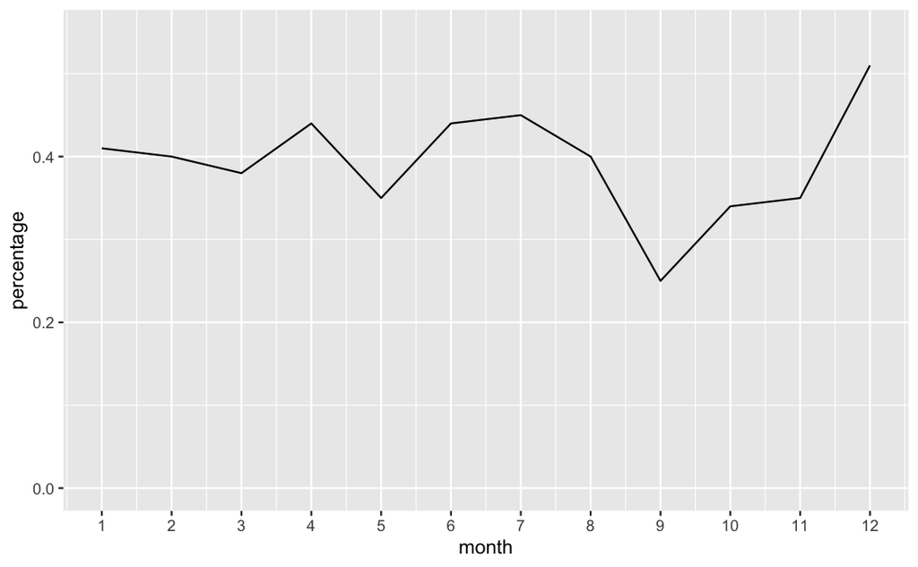

```r
flights |>
group_by(month)|> summarise(mean_delay = mean (arr_delay, na.rm =TRUE),
                            sd_delay = sd(arr_delay, na.rm = TRUE),
                            number_late = sum(arr_delay > 0, na.rm = TRUE),
                            total_number = n()) |>
                  mutate(percentage = number_late/total_number) |> round(2) |>
                  ggplot(aes(y = percentage, x = month )) +
                  geom_line() +
                  scale_x_continuous(breaks = 1:12) +
                  ylim(0,0.55)
```

## ICMA 9-22-2026

```r
delay_summary <- flights |>
  group_by(tailnum) |>
  summarize(mean_delay = mean(arr_delay, na.rm = TRUE),
  n_flights = n())
```

## ICMA 9-24-2026

```r
billboard_long <- billboard |>
  pivot_longer(cols = wk1:wk76,
               names_to = "week",
               values_to = "rank") |>
  head(10)
billboard |>
  filter(track == "Baby Don't Cry(Keep...")
```

| artist | track | date.entered | wk1 | wk2 | wk3 | wk4 | wk5 | wk6 | wk7 | wk8 | wk9 | wk10 | wk11 | wk12 | wk13 | wk14 | wk15 | wk16 | wk17 | wk18 | wk19 | wk20 | wk21 | wk22 | wk23 | wk24 | wk25 | wk26 | wk27 | … |
| --- | --- | --- | --- | --- | --- | --- | --- | --- | --- | --- | --- | --- | --- | --- | --- | --- | --- | --- | --- | --- | --- | --- | --- | --- | --- | --- | --- | --- | --- | --- |

```r
billboard_long_dropna <- billboard |>
  pivot_longer(cols = wk1:wk76,
               names_to = "week",
               values_to = "rank",
               values_drop_na = TRUE)
billboard_long_dropna |>
  filter(track == "Baby Don't Cry(Keep..." & week == "wk8")
```

| artist | track | date.entered | week | rank |
| --- | --- | --- | --- | --- |

```r
billboard_long_dropna %>%
  pivot_wider(names_from = week,
              values_from = rank)
```

| artist | track | date.entered | wk1 | wk2 | wk3 | wk4 | wk5 | wk6 | wk7 | wk8 | wk9 | wk10 | wk11 | wk12 | wk13 | wk14 | wk15 | wk16 | wk17 | wk18 | wk19 | wk20 | wk21 | wk22 | wk23 | wk24 | wk25 | wk26 | wk27 | … |
| --- | --- | --- | --- | --- | --- | --- | --- | --- | --- | --- | --- | --- | --- | --- | --- | --- | --- | --- | --- | --- | --- | --- | --- | --- | --- | --- | --- | --- | --- | --- |
| 2 Pac | Baby Don't Cry (Keep... | 2000-02-26 | 87 | 82 | 72 | 77 | 87 | 94 | 99 | NA | NA | NA | NA | NA | NA | NA | NA | NA | NA | NA | NA | NA | NA | NA | NA | NA | NA | NA | NA | … |
| 2Ge+her | The Hardest Part Of ... | 2000-09-02 | 91 | 87 | 92 | NA | NA | NA | NA | NA | NA | NA | NA | NA | NA | NA | NA | NA | NA | NA | NA | NA | NA | NA | NA | NA | NA | NA | NA | … |
| 3 Doors Down | Kryptonite | 2000-04-08 | 81 | 70 | 68 | 67 | 66 | 57 | 54 | 53 | 51 | 51 | 51 | 51 | 47 | 44 | 38 | 28 | 22 | 18 | 18 | 14 | 12 | 7 | 6 | 6 | 6 | 5 | 5 | … |
| 3 Doors Down | Loser | 2000-10-21 | 76 | 76 | 72 | 69 | 67 | 65 | 55 | 59 | 62 | 61 | 61 | 59 | 61 | 66 | 72 | 76 | 75 | 67 | 73 | 70 | NA | NA | NA | NA | NA | NA | NA | … |
| 504 Boyz | Wobble Wobble | 2000-04-15 | 57 | 34 | 25 | 17 | 17 | 31 | 36 | 49 | 53 | 57 | 64 | 70 | 75 | 76 | 78 | 85 | 92 | 96 | NA | NA | NA | NA | NA | NA | NA | NA | NA | … |
| 98^0 | Give Me Just One Nig... | 2000-08-19 | 51 | 39 | 34 | 26 | 26 | 19 | 2 | 2 | 3 | 6 | 7 | 22 | 29 | 36 | 47 | 67 | 66 | 84 | 93 | 94 | NA | NA | NA | NA | NA | NA | NA | … |
| A*Teens | Dancing Queen | 2000-07-08 | 97 | 97 | 96 | 95 | 100 | NA | NA | NA | NA | NA | NA | NA | NA | NA | NA | NA | NA | NA | NA | NA | NA | NA | NA | NA | NA | NA | NA | … |
| Aaliyah | I Don't Wanna | 2000-01-29 | 84 | 62 | 51 | 41 | 38 | 35 | 35 | 38 | 38 | 36 | 37 | 37 | 38 | 49 | 61 | 63 | 62 | 67 | 83 | 86 | NA | NA | NA | NA | NA | NA | NA | … |
| Aaliyah | Try Again | 2000-03-18 | 59 | 53 | 38 | 28 | 21 | 18 | 16 | 14 | 12 | 10 | 9 | 8 | 6 | 1 | 2 | 2 | 2 | 2 | 3 | 4 | 5 | 5 | 6 | 9 | 13 | 14 | 16 | … |
| Adams, Yolanda | Open My Heart | 2000-08-26 | 76 | 76 | 74 | 69 | 68 | 67 | 61 | 58 | 57 | 59 | 66 | 68 | 61 | 67 | 59 | 63 | 67 | 71 | 79 | 89 | NA | NA | NA | NA | NA | NA | NA | … |

[output cut: 307 more lines]

```r
billboard |>
  pivot_longer(cols = starts_with("wk"),
               names_to = "week",
               names_prefix = "wk",
               values_to = "rank",
               values_drop_na = TRUE)
```

| artist | track | date.entered | week | rank |
| --- | --- | --- | --- | --- |
| 2 Pac | Baby Don't Cry (Keep... | 2000-02-26 | 1 | 87 |
| 2 Pac | Baby Don't Cry (Keep... | 2000-02-26 | 2 | 82 |
| 2 Pac | Baby Don't Cry (Keep... | 2000-02-26 | 3 | 72 |
| 2 Pac | Baby Don't Cry (Keep... | 2000-02-26 | 4 | 77 |
| 2 Pac | Baby Don't Cry (Keep... | 2000-02-26 | 5 | 87 |
| 2 Pac | Baby Don't Cry (Keep... | 2000-02-26 | 6 | 94 |
| 2 Pac | Baby Don't Cry (Keep... | 2000-02-26 | 7 | 99 |
| 2Ge+her | The Hardest Part Of ... | 2000-09-02 | 1 | 91 |
| 2Ge+her | The Hardest Part Of ... | 2000-09-02 | 2 | 87 |
| 2Ge+her | The Hardest Part Of ... | 2000-09-02 | 3 | 92 |

[output cut: 990 more lines]

```r
billboard |>
  separate(col = date.entered,
           into = c("year","month","day"),            sep = ","
           ) |>
  unite(col = date_entered,
        year:day,
        sep = ",",
        remove = TRUE
        )
```

| artist | track | date_entered | wk1 | wk2 | wk3 | wk4 | wk5 | wk6 | wk7 | wk8 | wk9 | wk10 | wk11 | wk12 | wk13 | wk14 | wk15 | wk16 | wk17 | wk18 | wk19 | wk20 | wk21 | wk22 | wk23 | wk24 | wk25 | wk26 | wk27 | … |
| --- | --- | --- | --- | --- | --- | --- | --- | --- | --- | --- | --- | --- | --- | --- | --- | --- | --- | --- | --- | --- | --- | --- | --- | --- | --- | --- | --- | --- | --- | --- |
| 2 Pac | Baby Don't Cry (Keep... | 2000-02-26,NA,NA | 87 | 82 | 72 | 77 | 87 | 94 | 99 | NA | NA | NA | NA | NA | NA | NA | NA | NA | NA | NA | NA | NA | NA | NA | NA | NA | NA | NA | NA | … |
| 2Ge+her | The Hardest Part Of ... | 2000-09-02,NA,NA | 91 | 87 | 92 | NA | NA | NA | NA | NA | NA | NA | NA | NA | NA | NA | NA | NA | NA | NA | NA | NA | NA | NA | NA | NA | NA | NA | NA | … |
| 3 Doors Down | Kryptonite | 2000-04-08,NA,NA | 81 | 70 | 68 | 67 | 66 | 57 | 54 | 53 | 51 | 51 | 51 | 51 | 47 | 44 | 38 | 28 | 22 | 18 | 18 | 14 | 12 | 7 | 6 | 6 | 6 | 5 | 5 | … |
| 3 Doors Down | Loser | 2000-10-21,NA,NA | 76 | 76 | 72 | 69 | 67 | 65 | 55 | 59 | 62 | 61 | 61 | 59 | 61 | 66 | 72 | 76 | 75 | 67 | 73 | 70 | NA | NA | NA | NA | NA | NA | NA | … |
| 504 Boyz | Wobble Wobble | 2000-04-15,NA,NA | 57 | 34 | 25 | 17 | 17 | 31 | 36 | 49 | 53 | 57 | 64 | 70 | 75 | 76 | 78 | 85 | 92 | 96 | NA | NA | NA | NA | NA | NA | NA | NA | NA | … |
| 98^0 | Give Me Just One Nig... | 2000-08-19,NA,NA | 51 | 39 | 34 | 26 | 26 | 19 | 2 | 2 | 3 | 6 | 7 | 22 | 29 | 36 | 47 | 67 | 66 | 84 | 93 | 94 | NA | NA | NA | NA | NA | NA | NA | … |
| A*Teens | Dancing Queen | 2000-07-08,NA,NA | 97 | 97 | 96 | 95 | 100 | NA | NA | NA | NA | NA | NA | NA | NA | NA | NA | NA | NA | NA | NA | NA | NA | NA | NA | NA | NA | NA | NA | … |
| Aaliyah | I Don't Wanna | 2000-01-29,NA,NA | 84 | 62 | 51 | 41 | 38 | 35 | 35 | 38 | 38 | 36 | 37 | 37 | 38 | 49 | 61 | 63 | 62 | 67 | 83 | 86 | NA | NA | NA | NA | NA | NA | NA | … |
| Aaliyah | Try Again | 2000-03-18,NA,NA | 59 | 53 | 38 | 28 | 21 | 18 | 16 | 14 | 12 | 10 | 9 | 8 | 6 | 1 | 2 | 2 | 2 | 2 | 3 | 4 | 5 | 5 | 6 | 9 | 13 | 14 | 16 | … |
| Adams, Yolanda | Open My Heart | 2000-08-26,NA,NA | 76 | 76 | 74 | 69 | 68 | 67 | 61 | 58 | 57 | 59 | 66 | 68 | 61 | 67 | 59 | 63 | 67 | 71 | 79 | 89 | NA | NA | NA | NA | NA | NA | NA | … |

[output cut: 307 more lines]

```r
NA
```

## ICMA 9-29-2026

```r
read_csv("Week5-1_ClassData.csv")
```

| subject_id | bonusPayment | score |
| --- | --- | --- |
| 1 | $2 | 2 |
| 2 | $10 | 8 |
| 3 | N/A | . |
| 4 | $6 | 9 |
| 5 | $4 | 3 |

## ICMA 10-8-2026

ICMA question: what’s the difference between these two code chunks? Are the outputs the same? \ The difference is the command mapping command used in the first chunk that is absent in the second chunk. The outputs are the same.

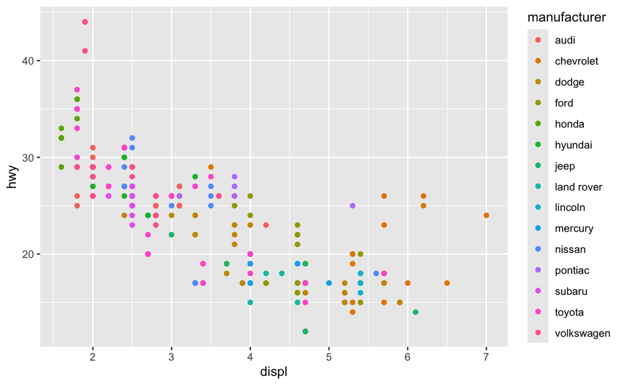

```r
mpg |>
  ggplot(mapping = aes(y = hwy, x = displ, color = manufacturer)) +
  geom_point()
```

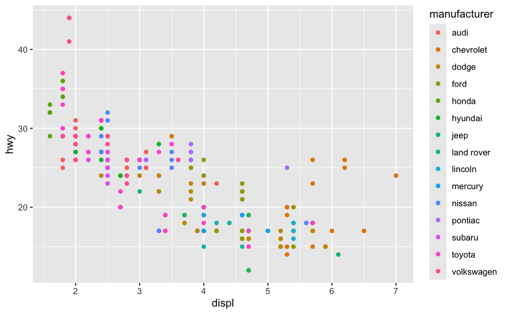

```r
mpg |>
  ggplot(aes(y = hwy, x = displ, color = manufacturer)) +
  geom_point()
```

ICMA question: what are these warnings about and why should we worry about them? **Answer**:These warnings are referring to the fact that in the shape palette you can only use 6 discrete values. This is a concern because if there are more than 6 data points there may be an error stating missing data if there are more then 6 data points and you are using shapes to represent them. Missing data could cause the graph to not be representative of the findings and the data at large.

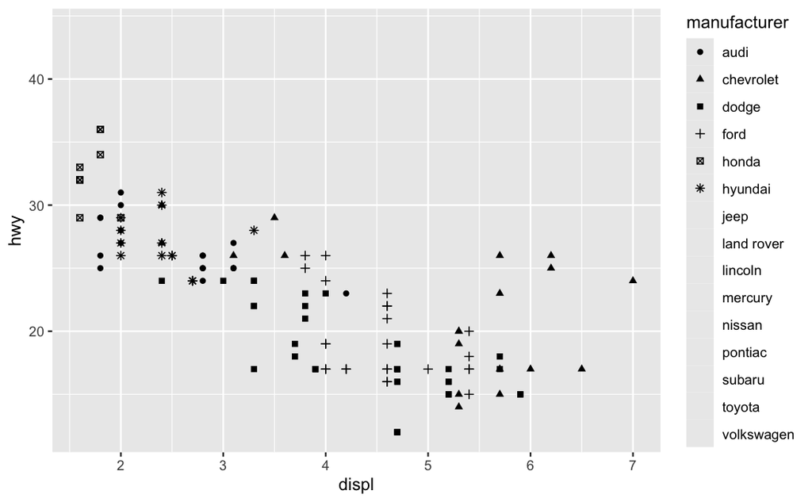

```r
mpg |>
  ggplot(aes(y = hwy, x = displ, shape = manufacturer)) +
  geom_point()
```

```r
#shows the the warning about the limit of 6 discrete values
```

Change the color of the line to something other than the default blue

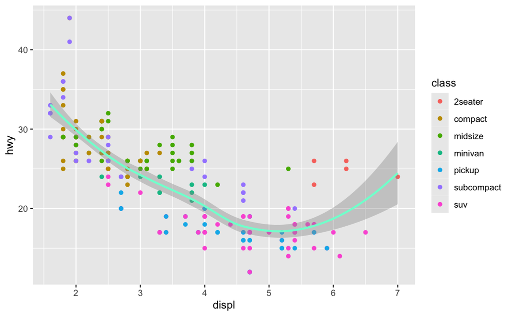

```r
ggplot(mpg, aes(x = displ, y = hwy)) +
  geom_point(aes(color = class)) +
  geom_smooth(color='aquamarine')
```

```r
#changed color of the line to 'aquamarine'
```

## ICMA 10-13-2026

Add a `facet_wrap`

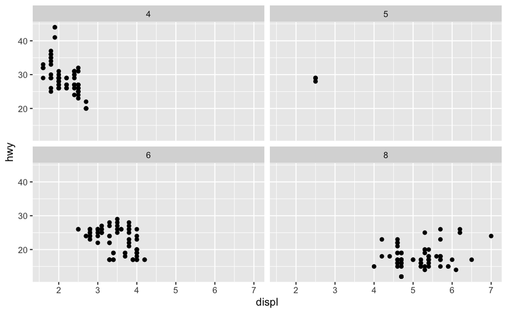

```r
mpg |>
  ggplot(aes(x = displ, y = hwy)) +
  geom_point() +
  facet_wrap(~cyl)
```

Set the number of columns to 4

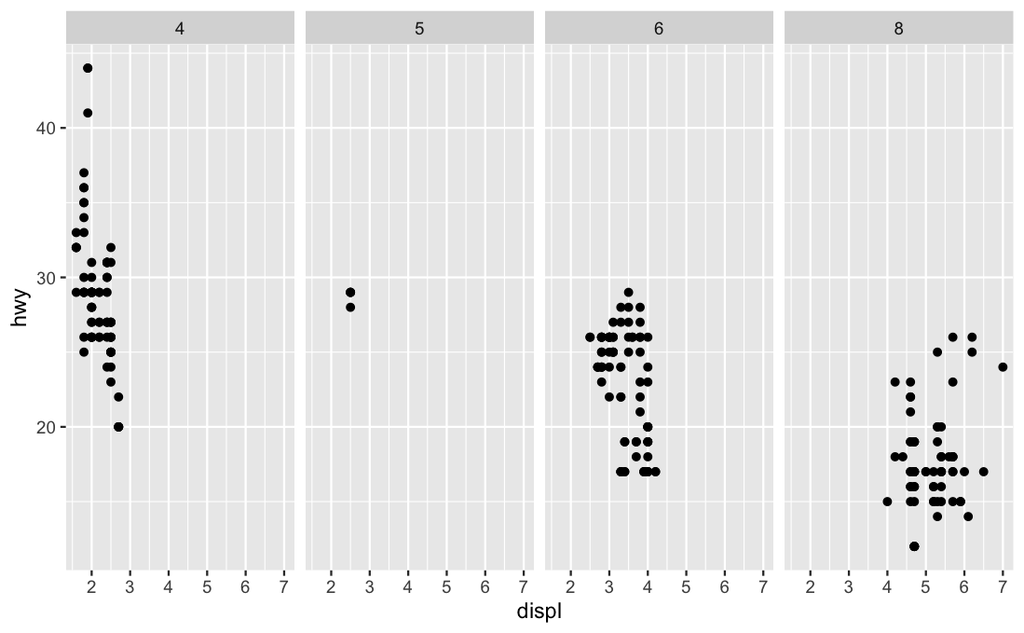

```r
mpg |>
  ggplot(aes(x = displ, y = hwy)) +
  geom_point() +
  facet_wrap(~cyl, ncol=4)
```

Set the number of rows to 4

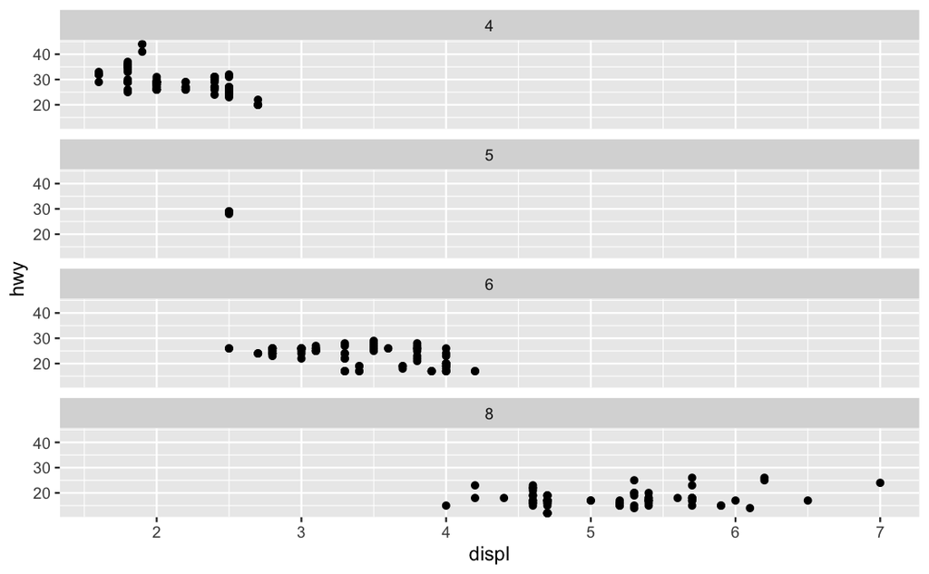

```r
mpg |>
  ggplot(aes(x = displ, y = hwy)) +
  geom_point()  +
  facet_wrap(~cyl, nrow=4)
```

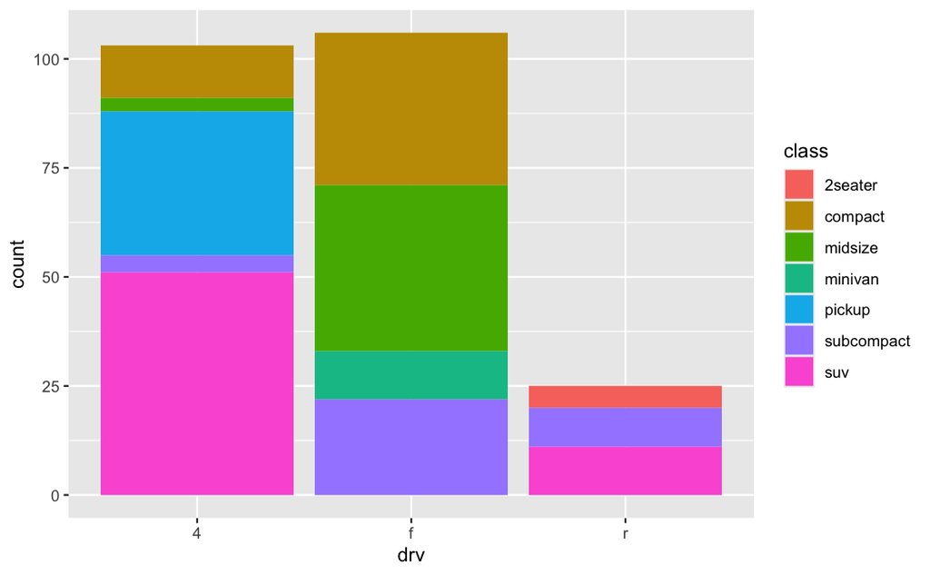

```r
ggplot(mpg,aes(x=drv,fill=class)) +
  geom_bar(position='stack')
```

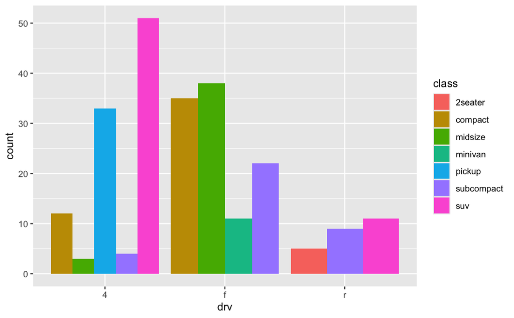

```r
ggplot(mpg,aes(x=drv,fill=class)) +
  geom_bar(position='dodge')
```

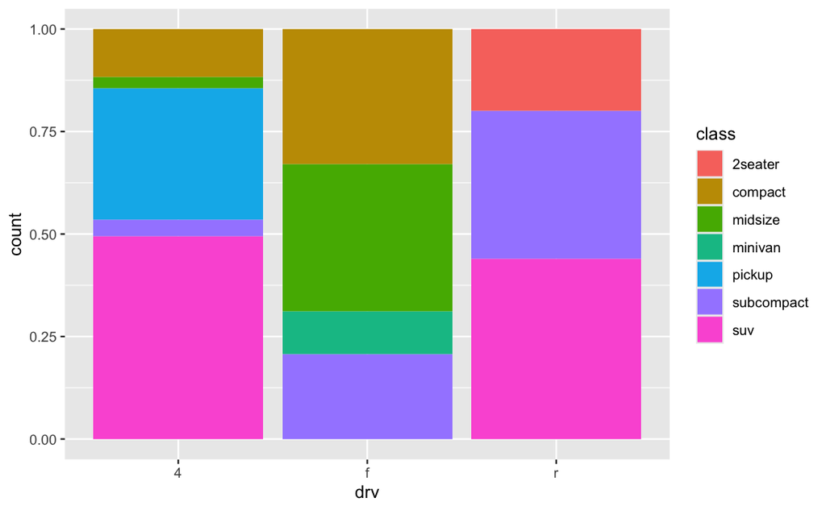

```r
ggplot(mpg,aes(x=drv,fill=class)) +
  geom_bar(position='fill')
```

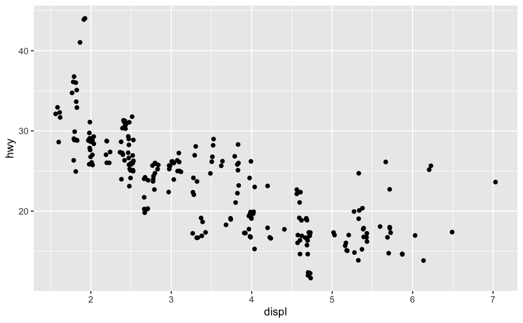

```r
ggplot(mpg, aes(x = displ, y = hwy)) +
  geom_point(position = 'jitter')
```

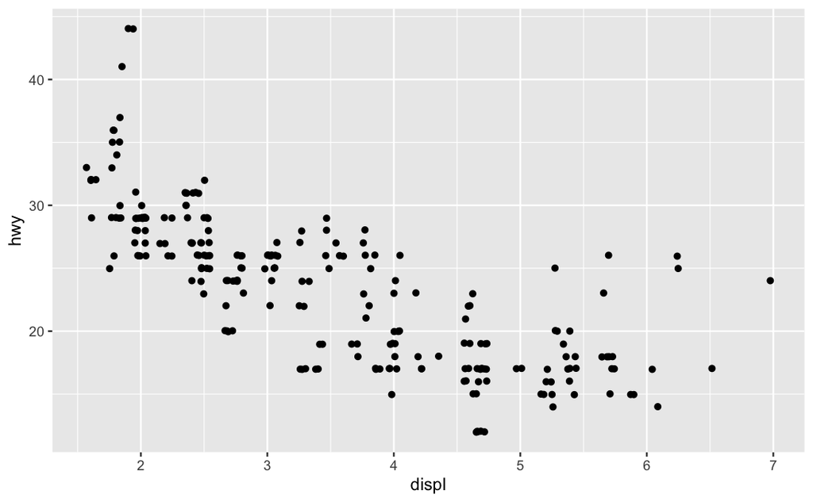

```r
ggplot(mpg, aes(x = displ, y = hwy)) +
  geom_jitter(width = 0.05,height=0.05)
```

Exercise: facet_grid (put this section in your ICMA file)

We want to add a facet using `facet_grid` that presents `drv` as rows and `cyl` as columns.

Do that below (if you need a hint, look at the supplement for Slide 14)

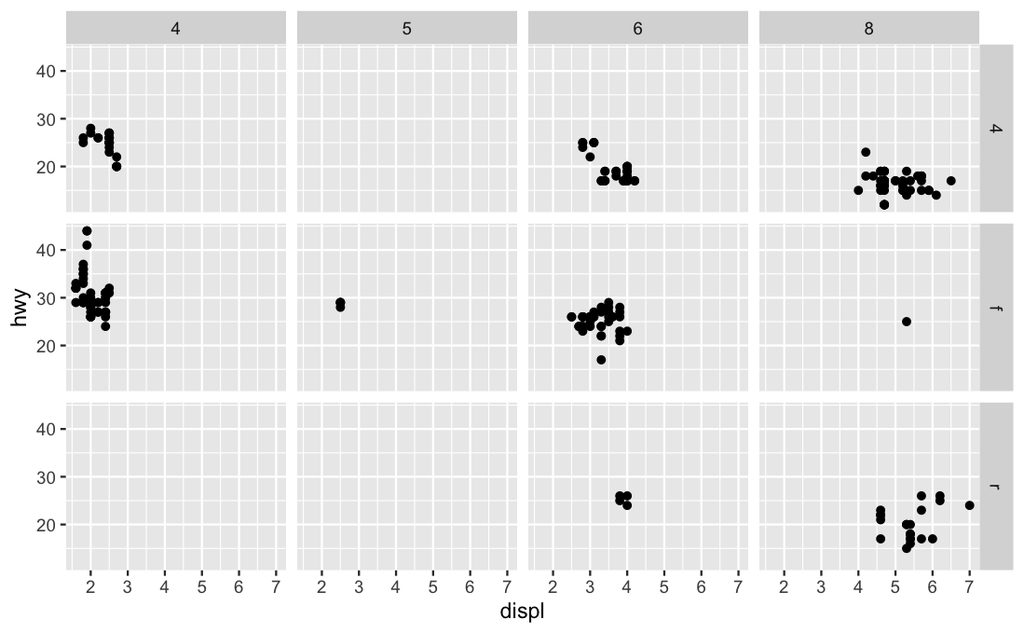

```r
ggplot(mpg, aes(x = displ, y = hwy)) +
  geom_point() +
  facet_grid(drv~cyl)
```

Let’s play with the x and y scales. First, call up the face_grid documentation.

```r
?facet_grid
```

What does the “scales” option do and what values does it take?

Below, experiment with facet_grid option, `scales = "free_x"`, `scales = "free_y"`, and `scales = 'free'`, and `scales = 'fixed'`. Compare with the code chunk above without scales being specified

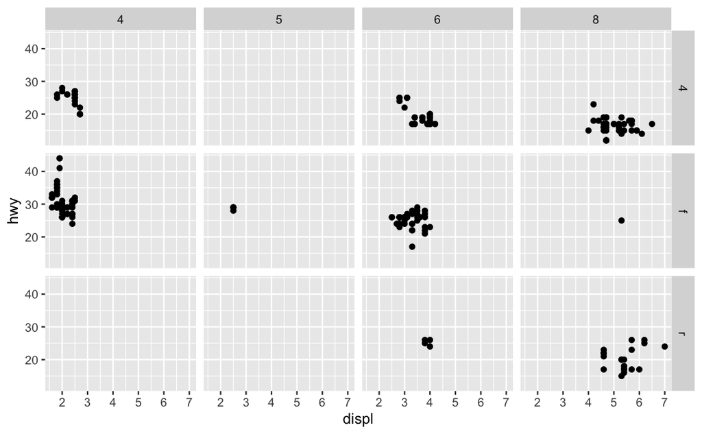

```r
ggplot(mpg, aes(x = displ, y = hwy)) +
  geom_point() +
  facet_grid(drv ~ cyl,scales = "fixed")
```

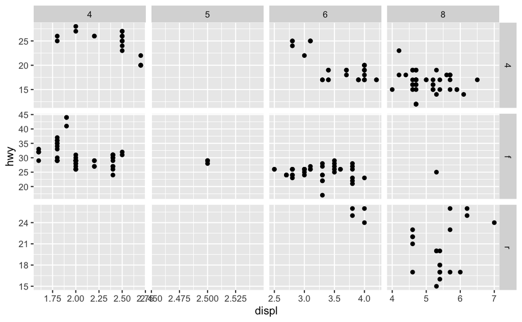

```r
ggplot(mpg, aes(x = displ, y = hwy)) +
  geom_point() +
  facet_grid(drv ~ cyl,scales ="free")
```

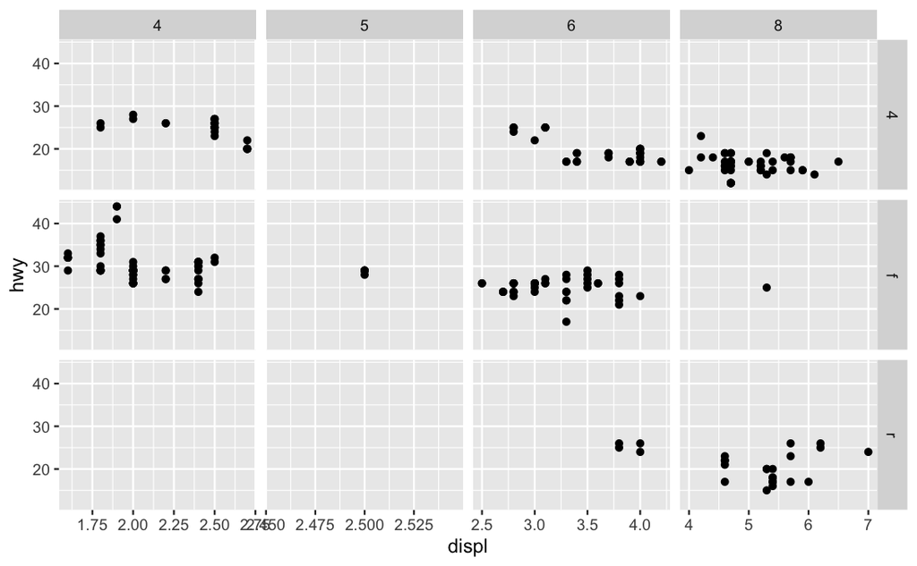

```r
ggplot(mpg, aes(x = displ, y = hwy)) +
  geom_point() +
  facet_grid(drv ~ cyl, scales = "free_x")
```

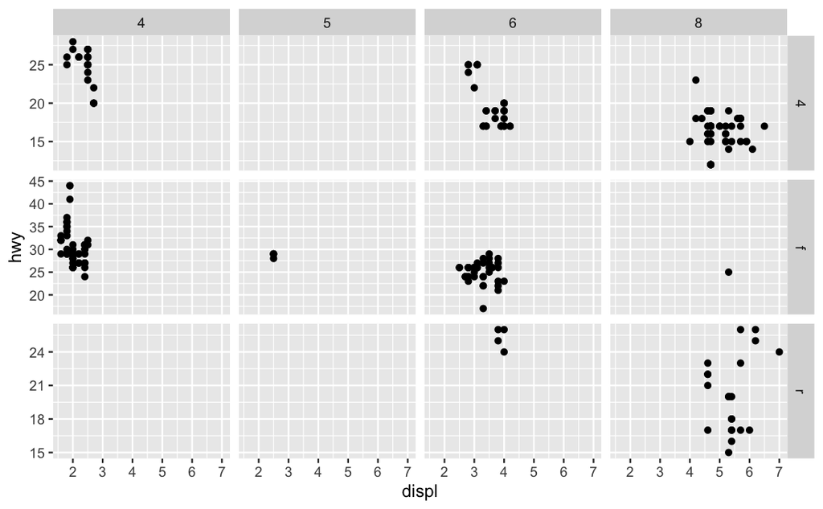

```r
ggplot(mpg, aes(x = displ, y = hwy)) +
  geom_point() +
  facet_grid(drv ~ cyl, scales = "free_y")
```

```r
NA
NA
```

Answer the following questions:

What effect does each option have on the plot? It allows different part of the data to be highlighted. Why might you want to use one of these options? Depending on the option its visually easier to compare clumps of data. What is the default `scales` value? The default is “fixed”.

## ICMA 10-15-2026

ICMA Exercise: faceted histograms

Using the `diamonds` dataset, create 2 plots.

1. A plot showing a histogram of diamond price
2. A plot showing a histogram of diamond price, **faceted** by color and cut

Choose a suitable bin width for your histogram(s). What influenced your choice?

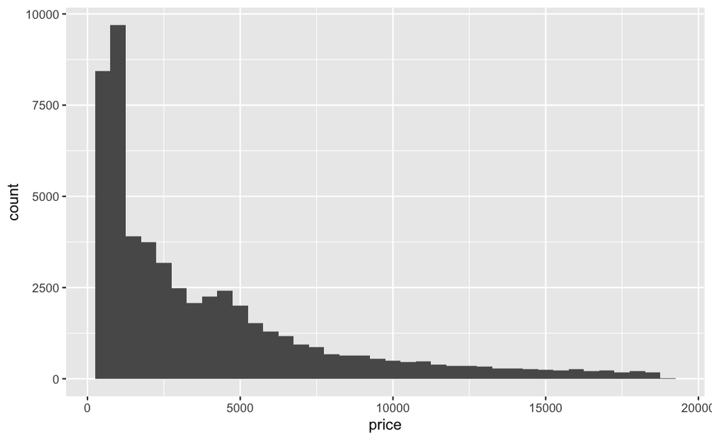

```r
ggplot(diamonds, aes(x = price)) +
  geom_histogram(binwidth = 500, linewidth = 0.85)
```

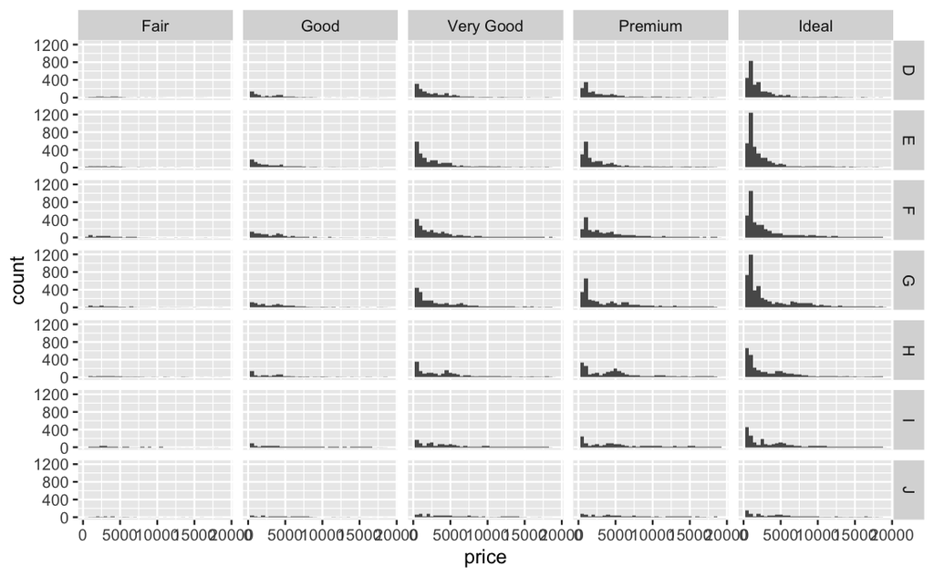

```r
 ggplot(diamonds) +
  aes(x = price) +
  geom_histogram (binwidth = 500) +
  facet_grid(color ~ cut)
```

ICMA Exercise: two variables

Using the `mpg` dataset plot a frequency polygon of the `hwy` variable, with the `class` variable mapped to the color aesthetic

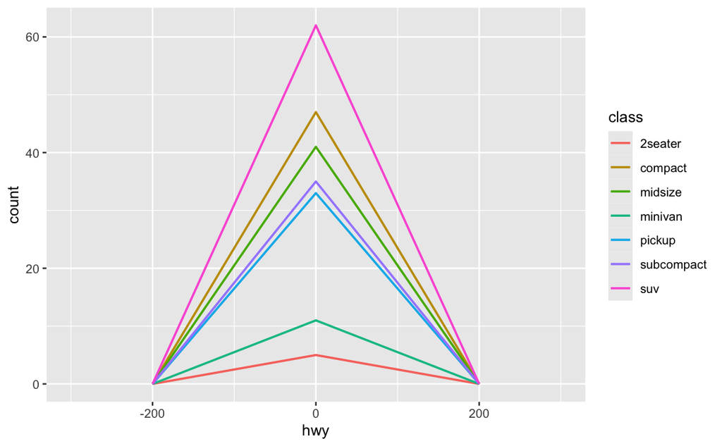

```r
ggplot(mpg, aes(x = hwy)) +
  geom_freqpoly(aes(color = class), binwidth = 200,linewidth = 0.75)
```

ICMA Exercise: histograms vs. boxplots

Below I have plotted a histograms and boxplots of the same data. Both plots show the variation of the `carat` variable from the `diamonds` data set.

Compare and contrast the two plots. What kind of information is highlighted by each? What kind of information is highlighted by both?

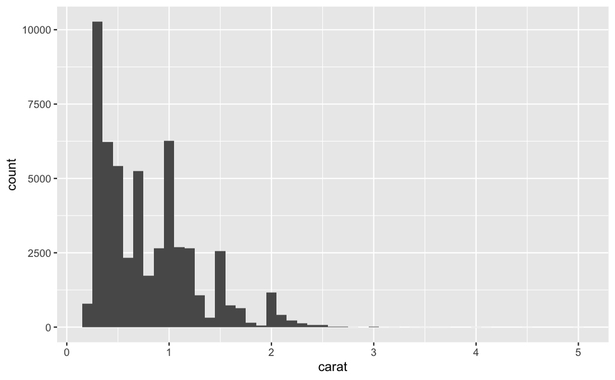

```r
ggplot(diamonds, aes(x = carat)) +
  geom_histogram(binwidth = 0.1)
```

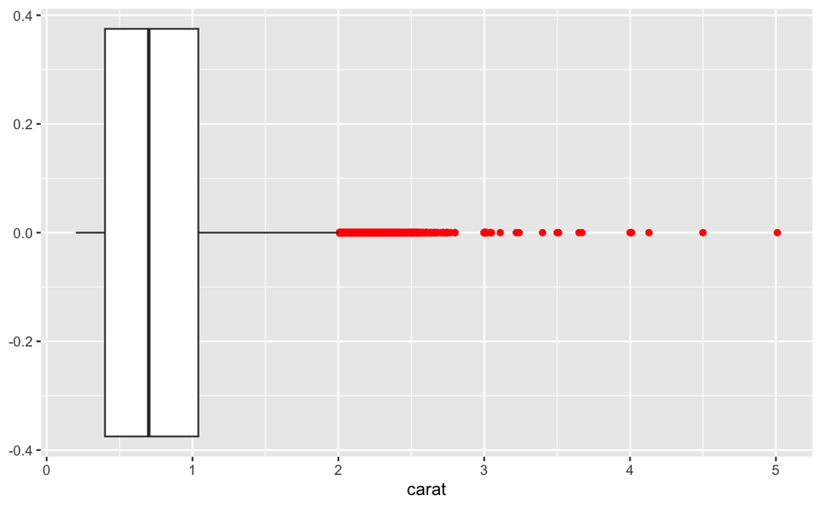

```r
diamonds |>
  ggplot(aes(x = carat)) +
  geom_boxplot(outlier.colour = 'red')
```

## ICMA 10-20-2026

ICMA Exercise (last class): two variables

Note: I have done some of these in the previous ICMA but decided to copy and paste them into the new ICMA I didn’t finish all of them previously just one I believe.

ICMA Exercise: two variables

Using the `mpg` dataset plot a frequency polygon of the `hwy` variable, with the `class` variable mapped to the color aesthetic

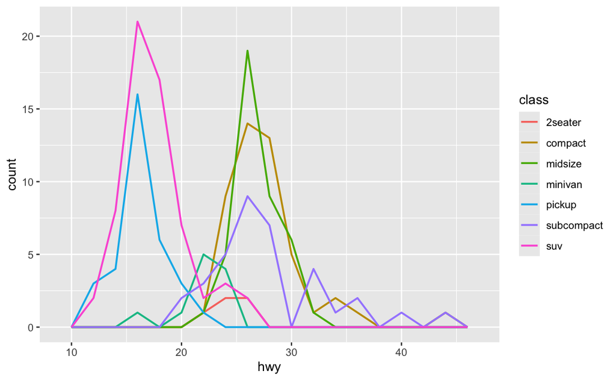

```r
ggplot(mpg, aes(x = hwy)) +
  geom_freqpoly(aes(color = class), binwidth = 2, linewidth = 0.75)
```

ICMA Exercise: histograms vs. boxplots

Below I have plotted a histograms and boxplots of the same data. Both plots show the variation of the `carat` variable from the `diamonds` data set.

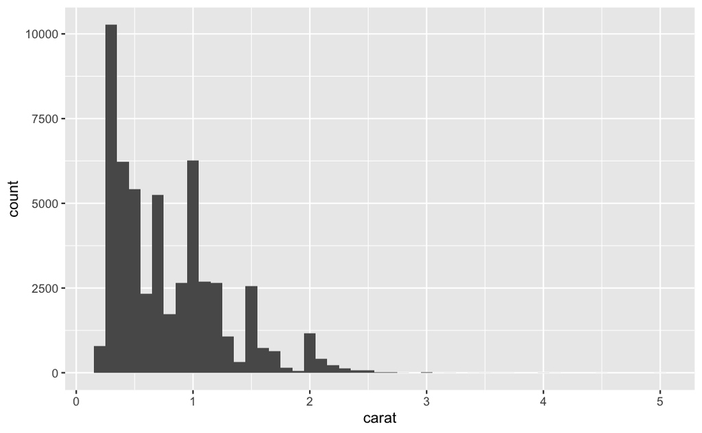

```r
ggplot(diamonds, aes(x = carat)) +
  geom_histogram(binwidth = 0.1)
```

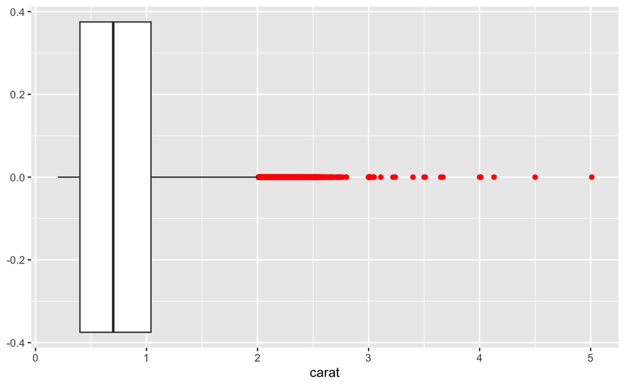

```r
diamonds |>
  ggplot(aes(x = carat)) +
  geom_boxplot(outlier.colour = 'red')
```

## ICMA 10-22-2026

ICMA Exercise: annotate (see code chunk for slide 27)

Create a plot using the `mpg`, `diamonds` or `nycflights13` data set and add an annotation to the plot.

Break this down into steps:

1. choose a dataset
2. inspect it using `glimpse` or `head`
3. decide what plot to create (will you show one variable, two variables, three variables?)
4. use the built-in help function to understand the geoms below
5. add the annotation!

Don’t get too hung up on whether your annotation is showing something useful, just annotate the plot to see how it works!

Some useful geoms to use for annotations are: -geom_vline -geom_hline -geom_rect -geom_segment -geom_label

```r
 diamonds |>
 glimpse()
```

```
Rows: 53,940
Columns: 10
$ carat   <dbl> 0.23, 0.21, 0.23, 0.29, 0.31, 0.24, 0.24, 0.26, 0.22, 0.23, 0.30, 0.23, 0.22, 0.31, 0.20…
$ cut     <ord> Ideal, Premium, Good, Premium, Good, Very Good, Very Good, Very Good, Fair, Very Good, G…
$ color   <ord> E, E, E, I, J, J, I, H, E, H, J, J, F, J, E, E, I, J, J, J, I, E, H, J, J, G, I, J, D, F…
$ clarity <ord> SI2, SI1, VS1, VS2, SI2, VVS2, VVS1, SI1, VS2, VS1, SI1, VS1, SI1, SI2, SI2, I1, SI2, SI…
$ depth   <dbl> 61.5, 59.8, 56.9, 62.4, 63.3, 62.8, 62.3, 61.9, 65.1, 59.4, 64.0, 62.8, 60.4, 62.2, 60.2…
$ table   <dbl> 55, 61, 65, 58, 58, 57, 57, 55, 61, 61, 55, 56, 61, 54, 62, 58, 54, 54, 56, 59, 56, 55, …
$ price   <int> 326, 326, 327, 334, 335, 336, 336, 337, 337, 338, 339, 340, 342, 344, 345, 345, 348, 351…
$ x       <dbl> 3.95, 3.89, 4.05, 4.20, 4.34, 3.94, 3.95, 4.07, 3.87, 4.00, 4.25, 3.93, 3.88, 4.35, 3.79…
$ y       <dbl> 3.98, 3.84, 4.07, 4.23, 4.35, 3.96, 3.98, 4.11, 3.78, 4.05, 4.28, 3.90, 3.84, 4.37, 3.75…
$ z       <dbl> 2.43, 2.31, 2.31, 2.63, 2.75, 2.48, 2.47, 2.53, 2.49, 2.39, 2.73, 2.46, 2.33, 2.71, 2.27…
```

```r
 ggplot(diamonds, aes(x = cut, y = count(TRUE)) +
+   geom_point(color = class) +
+   annotate(geom = "label", x = 3, y = 1,
             label = str_wrap("Colors and Diamonds fun!", width = 10),
+             hjust = 1, color = "aquamarine") +
```

```
Error: unexpected '=' in:
"             label = str_wrap("Colors and Diamonds fun!", width = 10),
+             hjust ="
```

ICMA Exercise: summarise and use axis labels (slide 31 and slide 24)

Here I want you to use the `label_currency` function to change the y-axis labels of a plot to show percentages for data plotted using the `diamonds` dataset.

There are two parts:

First, using `group_by` and `summarise`, I want you to create a table which shows the mean price of each cut of diamond.

Then plot this data using `geom_col,` making use of label_currency (similar to label_percentage in slide 31) to add currency symbols to the y-axis. Change the y-axis label to say “average price”

You will need the `scales` library to be installed and loaded

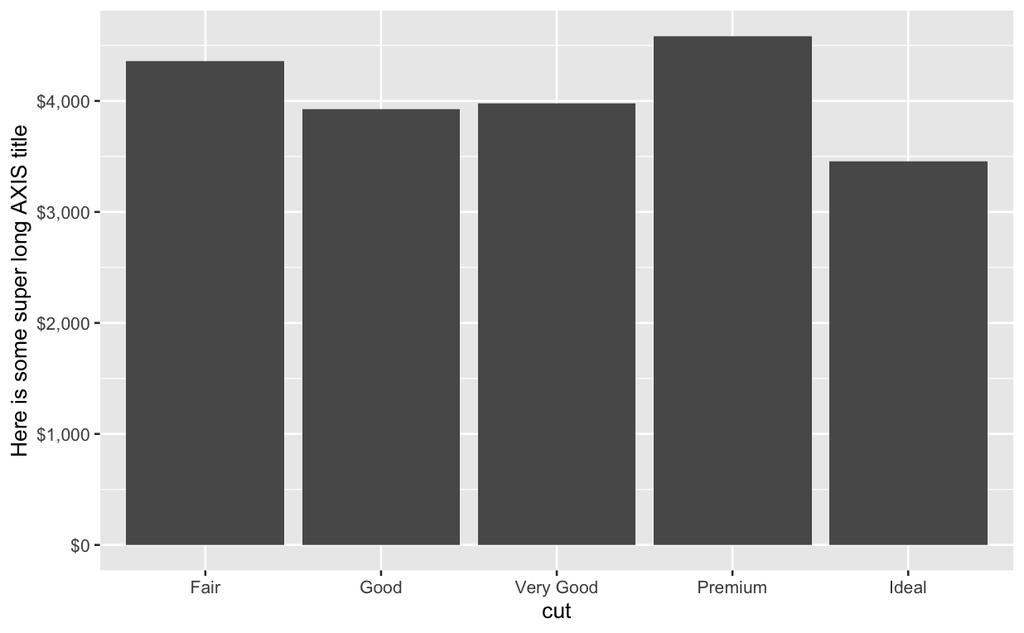

```r
library(scales)
diamonds |>
  group_by(cut) |>
  summarise(average_price = mean(price)) |>

ggplot(aes(x = cut, y = average_price)) +
  geom_col() +
  scale_y_continuous(labels = label_currency()) +
  labs(y= "Here is some super long AXIS title")
```